# Cyclistic Bike Share Analysis

# G. Data Visualization:

- Bar plot for average ride_length for two categories of member_casual:

```r
p1 <- cyclistic_df %>% group_by(member_casual) %>% summarize(min_ride_length = min(ride_length),max_ride_length = max(ride_length),mean_ride_length = mean(ride_length))
#minimum, maximum and mean ride_length for two casual_member categories
```

```r
p1
```

| member_casual | min_ride_length | max_ride_length | mean_ride_length |
| --- | --- | --- | --- |
| annual | 1 secs | 5627611 secs | 760.6268 secs |
| casual | 0 secs | 9387024 secs | 5747.1639 secs |

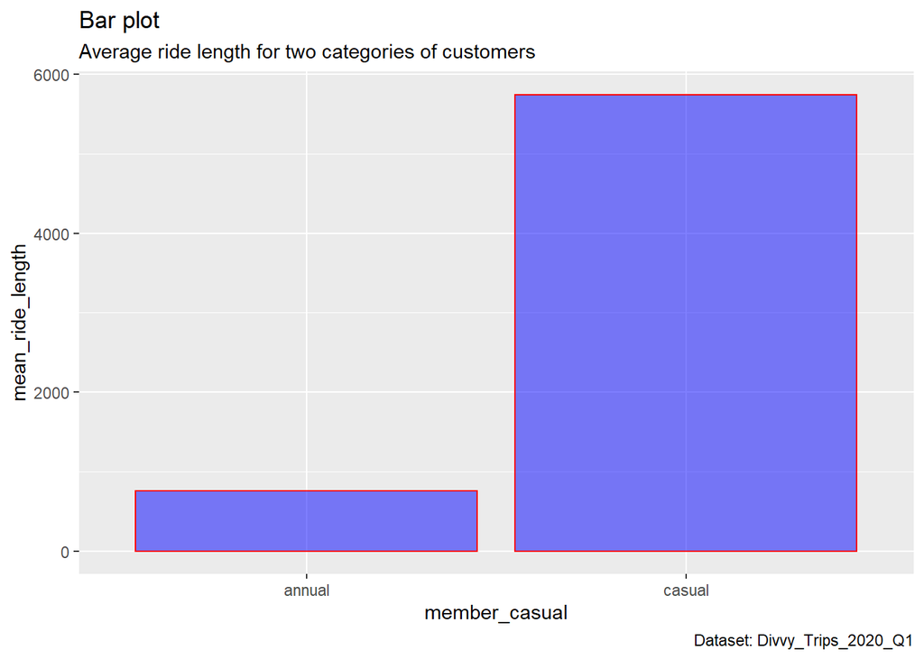

```r
ggplot(p1, aes(x = member_casual, y = mean_ride_length)) +
  labs(title = "Bar plot", subtitle = "Average ride length for two categories of customers", caption = "Dataset: Divvy_Trips_2020_Q1") +
  geom_bar(stat = "identity", fill = "blue", col = "red", alpha = 0.5)
```

```r
#bar plot for average ride_length
```

- Bar plot for average distance_km for two categories of member_casual:

```r
p2 <- cyclistic_df %>% group_by(member_casual) %>% summarize(min_distance_km = min(distance_km),max_distance_km = max(distance_km),mean_distance_km = mean(distance_km))
#minimum, maximum and mean distance_km for two casual_member categories
```

```r
p2
```

| member_casual | min_distance_km | max_distance_km | mean_distance_km |
| --- | --- | --- | --- |
| annual | 0 | 18.40971 | 1.833669 |
| casual | 0 | 23.02981 | 1.942117 |

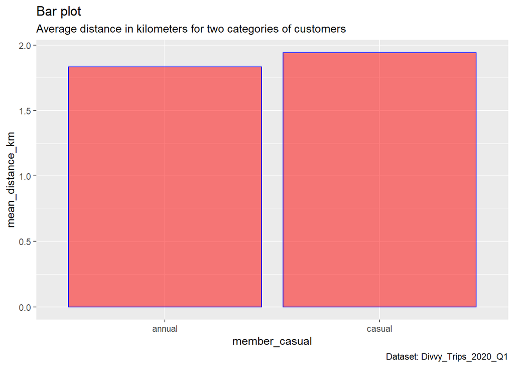

```r
ggplot(p2, aes(x = member_casual, y = mean_distance_km)) +
  labs(title = "Bar plot", subtitle = "Average distance in kilometers for two categories of customers", caption = "Dataset: Divvy_Trips_2020_Q1") +
  geom_bar(stat = "identity", fill = "red", col = "blue", alpha = 0.5)
```

```r
#bar plot for average distance_km traveled
```

- Histogram for distribution of distance_km traveled:

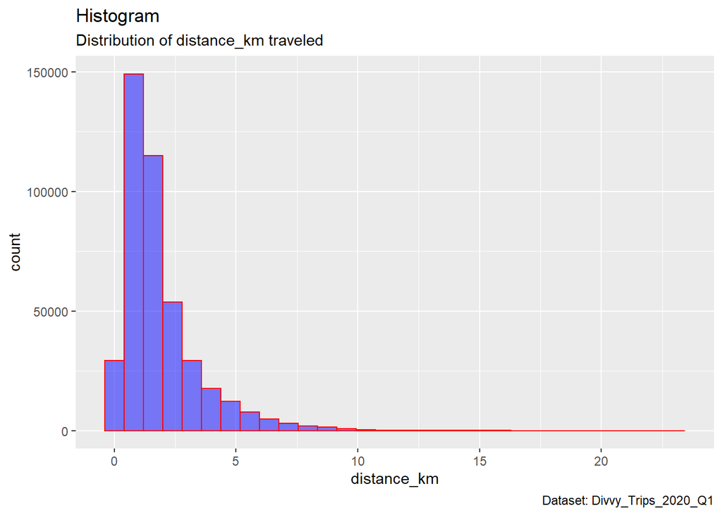

```r
ggplot(cyclistic_df, aes(x = distance_km)) +
  labs(title = "Histogram", subtitle = "Distribution of distance_km traveled", caption = "Dataset: Divvy_Trips_2020_Q1") +
  geom_histogram(fill = "blue", col = "red",alpha = 0.5)
```

```r
#histogram for distribution of distance_km
```

- Box plot for distribution of distance_km around Interquartile Range:

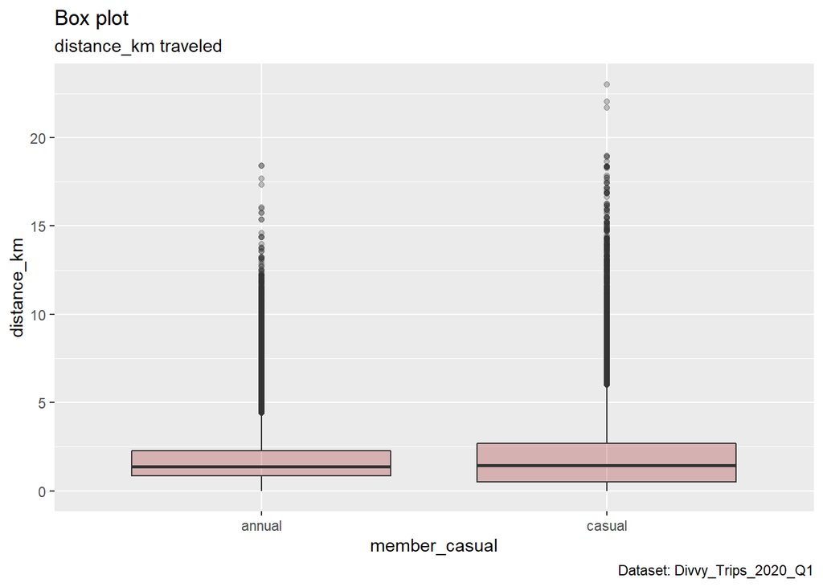

```r
ggplot(cyclistic_df, aes(x = member_casual, y = distance_km)) +
  labs(title = "Box plot", subtitle = "distance_km traveled", caption = "Dataset: Divvy_Trips_2020_Q1") +
  geom_boxplot(fill = "brown", alpha = 0.3)
```

```r
#box plot for distance_km traveled
```

- Bar graph for count of records for each day_of_week:

```r
p3 <- cyclistic_df %>% group_by(day_of_week) %>% count()
#count of records from each day_of_week
```

```r
p3
```

| day_of_week | n |
| --- | --- |
| Friday | 60663 |
| Monday | 66777 |
| Saturday | 37584 |
| Sunday | 50850 |
| Thursday | 66140 |
| Tuesday | 74961 |
| Wednesday | 69911 |

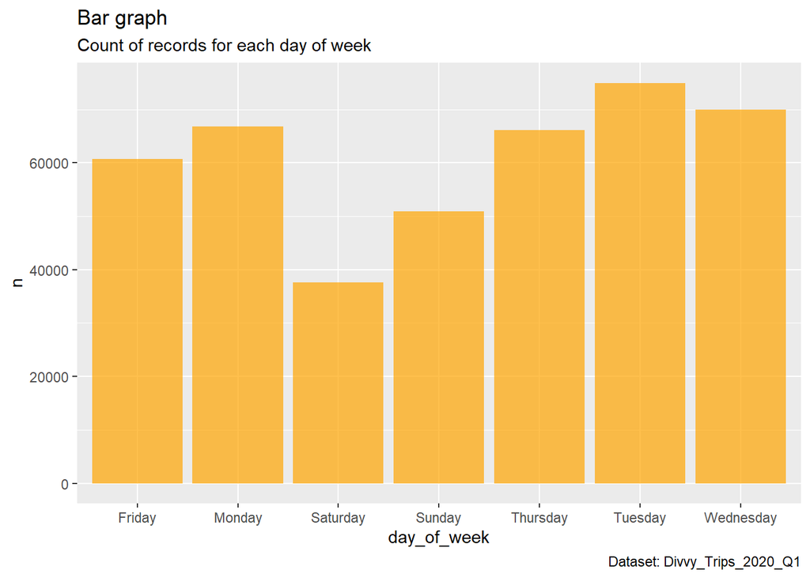

```r
ggplot(p3, aes(x = day_of_week, y = n)) +
  labs(title = "Bar graph", subtitle = "Count of records for each day of week", caption = "Dataset: Divvy_Trips_2020_Q1") +
  geom_bar(stat = "identity", fill = "orange", alpha = 0.7)
```

```r
#bar graph for count of records
```

- Bar plot for average distance_km for each day_of_week:

```r
p4 <- cyclistic_df %>% group_by(day_of_week) %>% summarise(mean_distance_km = mean(distance_km))
```

```r
p4
```

| day_of_week | mean_distance_km |
| --- | --- |
| Friday | 1.763745 |
| Monday | 1.824828 |
| Saturday | 1.851340 |
| Sunday | 2.043713 |
| Thursday | 1.816049 |
| Tuesday | 1.843580 |
| Wednesday | 1.821757 |

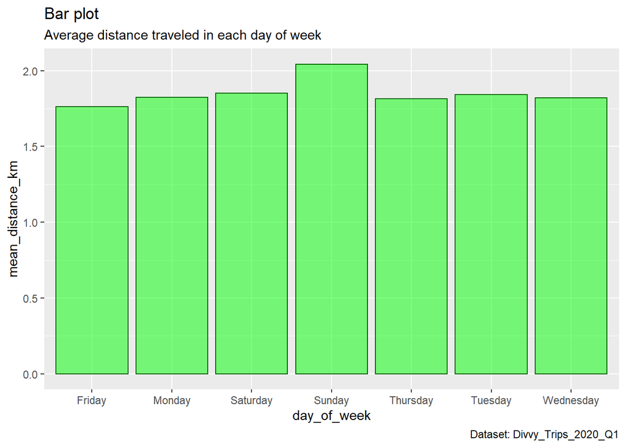

```r
ggplot(p4,aes(x = day_of_week, y = mean_distance_km)) +
  labs(title = "Bar plot", subtitle = "Average distance traveled in each day of week", caption = "Dataset: Divvy_Trips_2020_Q1") +
  geom_bar(stat = "identity", fill = "green", col = "darkgreen", alpha = 0.5)
```

```r
#bar plot for average distance_km traveled
```

- Scatter plot with regression line between ride_length and distance_km:

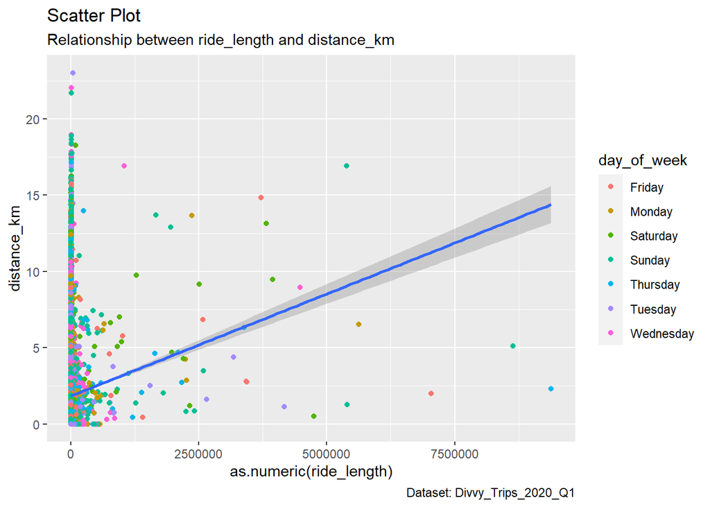

```r
ggplot(data=cyclistic_df) +
  labs(title = "Scatter Plot", subtitle = "Relationship between ride_length and distance_km", caption = "Dataset: Divvy_Trips_2020_Q1") +
  geom_point(mapping = aes(x = as.numeric(ride_length), y = distance_km, color = day_of_week), position = position_jitter())  +
  stat_smooth(mapping = aes(x = as.numeric(ride_length), y = distance_km), method = "lm", formula = y~x)
```

```r
#scatter plot for ride_length vs distance_km
```

- Heatmap for distance_km travelled in each day_of_week by two categories of bike share customers:

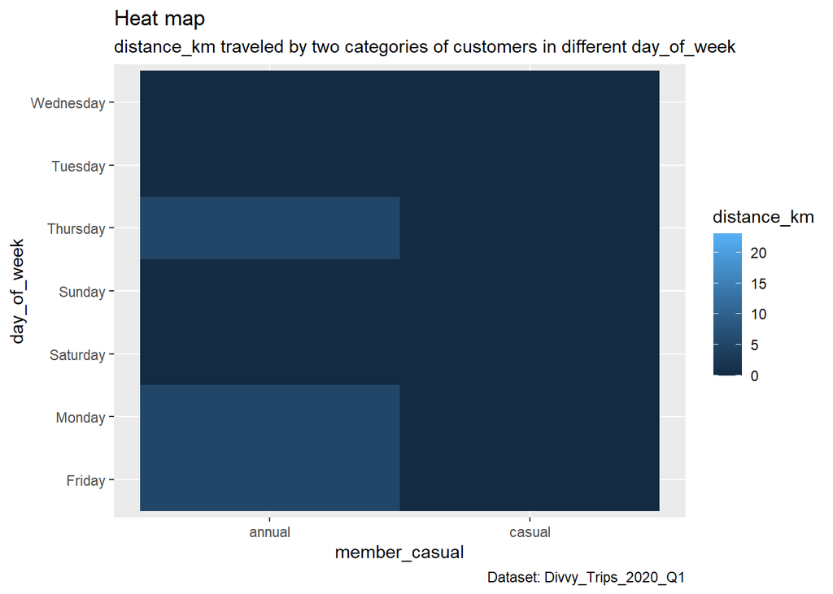

```r
ggplot(cyclistic_df, aes(x = member_casual, y = day_of_week, fill = distance_km )) +
  labs(title = "Heat map", subtitle = "distance_km traveled by two categories of customers in different day_of_week", caption = "Dataset: Divvy_Trips_2020_Q1") +
  geom_tile()
```

```r
#heatmap for distance_km
```